# Midterm STT 5811

Huy Tu

2015-11-02

**Midterm Directions:** Answer all questions to the midterm with complete sentences. Make sure to show all code and use inline code when reporting numerical answers to questions. The Gettysburg address is stored in the `Data` folder of the class repository as `GA.csv`. Please italicize all answers. Create a directory under your private GitHub repository named `MidTerm`. Move this document (`MidTerm5811.Rmd`) to your `MidTerm` directory as well as the `GA.csv` file. Push your completed work to your private repository no later than 17:00 October 9, 2015.

1. Read the Gettysburg address into an object named `GA` using the `read.csv` function (use `colClasses = "character"`). Convert all words used in the Gettysburg address to lower case using the function `tolower`. Show the first six words in the object `GA`. [2 pts]

```r
> a <- read.csv('GA.csv', colClasses = "character")
> a$words <- tolower(c(a$words))
> for (i in 1:6 ) {
+   print(a$words[i])
+ }
```

```
[1] "four"
[1] "score"
[1] "and"
[1] "seven"
[1] "years"
[1] "ago"
```

2. Set the seed value to 649 (`set.seed(649)`). Use the function `sample` to take a simple random sample of size 10 from the Gettysburg address and store the results in the object `SAMPLE10`. Show the results of `SAMPLE10`. [2 pts]

```r
> set.seed(649)
> n = 10
> SAMPLE10 <- sample(a$words, size=n, replace = FALSE)
> SAMPLE10
```

```
 [1] "so"      "fathers" "have"    "highly"  "it"      "have"    "new"
 [8] "be"      "this"    "that"
```

3. Consider the following variables and identify each as quantitative or categorical: [2 pts]
- length of word (number of letters) - Type: *quantitative*
- whether or not word contains the letter `e` - Type: *categorical*
4. Use the package `stringi` and write `R` code to determine the string length of each word in `SAMPLE10`. Create a logical vector indicating whether each word in `SAMPLE10` contains one or more `e`s. Use `R` code to count the number of words containing one or more `e`s in `SAMPLE10`. [4 pts]

```r
> STR_L <- stri_length(SAMPLE10)
> STR_L
```

```
 [1] 2 7 4 6 2 4 3 2 4 4
```

```r
> STR_E <- stri_count_fixed(SAMPLE10, 'e')>=1
> STR_E <- sum(STR_E)
> STR_E
```

```
[1] 5
```

- *The number of words containing one or more `e`s in `SAMPLE10` is 5.*
5. What is the average word length for `SAMPLE10`? [2 pts]

```r
> AVG_W_L <- mean(STR_L)
> AVG_W_L
```

```
[1] 3.8
```

- *The average word length for `SAMPLE10` is 3.8.*
6. Is the average length you calculated in e. a parameter or a statistic? Explain. Do we know its value? What symbol can we use to denote its value? [3 pts]
- *The calculated result in e of the average word length is a statistic because the value comes from a simple random sample and not the entire population.*
- *Yes, we know its value which is 3.8*
- *The symbol we can use to denote its value is $\bar{x}$.*
7. The average length of all 268 words in this population is 4.2947761 letters. Is this number a parameter or a statistic? Do we know its value? What symbol can we use to denote its value? [3 pts]

```r
> P_Mean <- mean(stringi::stri_length(GA$words))
> P_Mean
```

```
[1] 4.294776
```

- *This number would be a parameter because it is the value indicating the mean of the whole entire population.*
- *Yes, we know its value which is 4.2947761*
- *The symbol use to denote its value is $\mu$.*
8. Simulate $m = 150$ students each taking a simple random sample (of size $n = 10$) of the words in the Gettysburg address. Use a seed of 55. Store the length of each word in an `R` object (Hint: use a matrix). Construct a dotplot displaying the average word length of the SRS for each of the the $m = 150$ students. [12 pts]

*This simulation pretends there are $m=150$ students.*

```r
> set.seed(55)
>
> m = 150
> n = 10
>
> A = matrix(NA, ncol = n, nrow = m)
>
> for (i in 1:m) {
+   SAMPLE_M <- sample(a$words, size=10, replace = FALSE)
+   A[i,] = stri_length(SAMPLE_M)
+ }
> DF <- data.frame(AVG_LEN = apply(A, 1, mean))
> head(DF)
```

```
  AVG_LEN
1     4.3
2     4.1
3     6.0
4     3.7
5     4.7
6     4.0
```

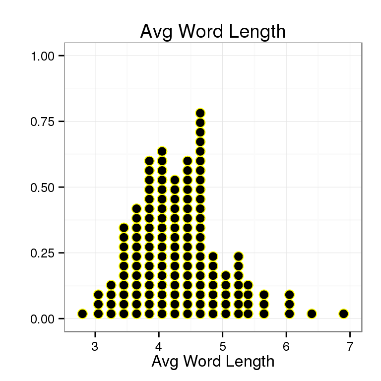

```r
> library(ggplot2)
> ggplot(data = DF, aes(x = AVG_LEN)) +
+   geom_dotplot(binwidth = .15, color = "yellow") +
+   labs(title = "Avg Word Length", x = "Avg Word Length", y = " ") + theme_bw()
```

1. Characterize the distribution of these sample means. [3 pts]

```r
> summary(DF$AVG_LEN)
```

```
   Min. 1st Qu.  Median    Mean 3rd Qu.    Max.
  2.800   3.900   4.300   4.325   4.675   6.900
```

```r
> Five_SUM <- fivenum(DF$AVG_LEN)
> S_MED <-median(DF$AVG_LEN, na.rm = TRUE)
> S_MED
```

```
[1] 4.3
```

```r
> IQRspread <-IQR(DF$AVG_LEN, na.rm = TRUE)
> IQRspread
```

```
[1] 0.775
```

- *The distribution is unimodal and skewed right with a median of 4.3, minimum of 2.8, maximum of 6.9, and spread of 0.775.*
10. Write `R` code that determines how many and what proportion of the $m = 150$ simulated students had a sample mean word length that exceeded the population mean word length? [2 pts]

```r
> population_mean <- mean(DF$AVG_LEN)
> population_mean
```

```
[1] 4.324667
```

```r
> count = 0
> for (i in 1:(m)) {
+   if(DF$AVG_LEN[i] > population_mean)
+   {
+     count = count + 1
+   }
+ }
> count
```

```
[1] 70
```

```r
> prop <- count/m
> prop
```

```
[1] 0.4666667
```

```r
> set.seed(34)
>
> m = 10000
> n = 81
> k = 8
>
> A = matrix(NA, ncol = n, nrow = m)
>
> for (i in 1:m) {
+   SAMPLE_M <- sample(a$words, size=n, replace = FALSE)
+   A[i,] = stri_length(SAMPLE_M)
+ }
>
> DF <- data.frame(AvgLen = apply(A, 1, mean))
> head(DF)
```

```
    AvgLen
1 4.395062
2 4.654321
3 4.308642
4 4.209877
5 4.037037
6 4.518519
```

```r
> for (j in 1:k) {
+   print(DF$AvgLen[j])
+ }
```

```
[1] 4.395062
[1] 4.654321
[1] 4.308642
[1] 4.209877
[1] 4.037037
[1] 4.518519
[1] 3.876543
[1] 4.444444
```

12. Compute the population mean ($\mu_{\bar{x}}$) and population standard deviation for average word length ($\sigma_{\bar{x}}$) of the Gettysburg address storing the results in the objects `EW` and `SWA`, respectively. Make sure to use a finite population correction factor, $(N - n)/(N - 1)$, when computing $\sigma_{\bar{x}}$. Store the value for $\sigma_{\bar{x}}$ without a finite population correction factor in `SW`. Compute the mean and standard deviation of the values in `AvgLen`. [12 pts]

```r
> N<-length(a$words)
> n<-81
> EW<-mean(stringi::stri_length(a$words))     #population mean
> EW
```

```
[1] 4.294776
```

```r
> T_WL <-table(stri_length(a$words))
> T_WL
```

```
 1  2  3  4  5  6  7  8  9 10 11
 7 49 54 59 34 27 15  6 10  4  3
```

```r
> T_Vectors <-as.numeric(names(T_WL))
> T_Prop <-T_WL/N                             # Theoretical Probability
> FPC<-(N-n)/(N-1)                            # Finite correction
> SWA<-sqrt(sum((T_Vectors-EW)^2*T_Prop)*FPC) # SD with correction
> SW<-sqrt(sum((T_Vectors-EW)^2*T_Prop))      # SD without correction
> SWA
```

```
[1] 1.773614
```

```r
> SW
```

```
[1] 2.119308
```

```r
> EW2<-mean(DF$AvgLen)
> EW2
```

```
[1] 4.295963
```

```r
> T_WL2<-table(DF$AvgLen)
> T_Vectors2<-as.numeric(names(T_WL2))
> PT2<-T_WL2/length(DF$AvgLen)                # Theoretical Probability
> PT2
```

[output not shown]

```r
> FPC<-(N-n)/(N-1)                            # Finite correction
> SWA2<-sqrt(sum((T_Vectors2-EW2)^2*PT2)*FPC) # SD with correction
> SW2<-sqrt(sum((T_Vectors2-EW2)^2*PT2))      # SD without correction
> SW2
```

```
[1] 0.1972818
```

13. Based on your results, explain whether or not your simulation of $m = 10000$ students each taking a simple random sample of size $n = 81$ can be used to obtain an unbiased estimate of $\mu$. [3 pts]
- *Based on my results, my stimulation of $m = 10000$ students each taking a simple random sample of size $n = 81$ can be used to obtain an unbiased estimate of $\mu$ because the result of 4.295963 is closed to 4.2947761.*
14. Create a density plot of the values in `AvgLen`. Superimpose a normal distribution with a darkgreen line over the density plot using the parameters stored in `EW` and `SWA` for the mean and standard deviation respectively. Superimpose a second normal distribution with a lightblue line over the density plot using the parameters stored in `EW` and `SW` for the mean and standard deviation respectively. Does the darkgreen or lightblue line provide a better model for sampling without replacement? [10 pts]

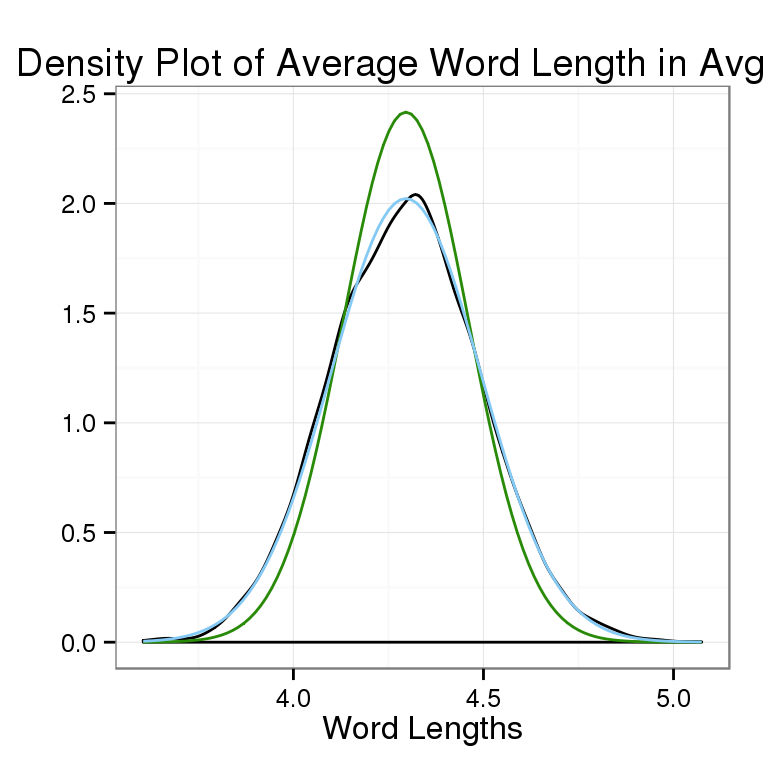

```r
> library(ggplot2)
> DFA <- data.frame(AvgLen = DF$AvgLen)
> ## Using ggplot
> ggplot(DFA,aes(x=AvgLen)) +
+    geom_density(binwidth=.15) +
+    labs(x = "Word Lengths",y = "",
+         title = "Density Plot of Average Word Length in AvgLen") +
+    theme_bw() +
+    stat_function(fun = dnorm, args = list(PT2,mean = EW2, sd = SWA2), colour = "#298A08") +
+    stat_function(fun = dnorm, args = list(PT2,mean = EW2, sd = SW2), colour = "#85CAF5")
```

- *The lightblue line provides a better model for sampling without replacement*
15. Suppose you wanted to achieve sample means that tended to fall even closer to the population mean, would you increase the sample size or the number of samples? [2 pts]
- *I personally would increase the sample size. A larger sample size would decrease the value of standard deviation or less variation and increase the precision of the sample means to fall even closer to the population mean.*
16. Use `set.seed = 145` to select a simple random sample of size ($n = 5$) from the words in the Gettysburg address and store the results in the object `SAMPLE`. Write `R` code to determine the proportion of the words in `SAMPLE` that contain the letter `e`. [3 pts]

```r
> set.seed(145)
> n = 5
> SAMPLE <- sample(a$words, size=5, replace = FALSE)
> SAMPLE
```

```
[1] "that"     "little"   "highly"   "have"     "advanced"
```

```r
> STR_E2 <- sum(stri_count_fixed(SAMPLE, 'e')>=1)
> STR_E2
```

```
[1] 3
```

```r
> prop <- STR_E2/n
> prop
```

```
[1] 0.6
```

- *The proportion of the words in `SAMPLE` that contain the letter `e` is 0.6.*
17. Construct 95% confidence intervals for $\pi$ the true proportion of words in the Gettysburg address that have at least one `e` using the Wald (asymptotic) and Agresti-Coull methods using the values obtained in (s). What is the actual value for $\pi$? Do either or both of the constructed confidence intervals contain $\pi$? Interpret the constructed confidence intervals. [10 pts]

```r
> N<-length(GA$words)
> prop
```

```
[1] 0.6
```

```r
> Wlsi <-prop-1.96*sqrt(prop*(1-prop)/5)
> Wrsi <-prop+1.96*sqrt(prop*(1-prop)/5)
> Wlsi
```

```
[1] 0.1705855
```

```r
> Wrsi
```

```
[1] 1.029414
```

```r
> prop2 <- (STR_E2+2)/(n+4)
> Alsi  <- prop2-1.96*sqrt(prop2*(1-prop2)/(n+4))
> Arsi  <- prop2+1.96*sqrt(prop2*(1-prop2)/(n+4))
> Alsi
```

```
[1] 0.2309116
```

```r
> Arsi
```

```
[1] 0.8801995
```

```r
> Pi <- sum(stri_count_fixed(a$words,"e")>=1)/N
> Pi
```

```
[1] 0.4664179
```

- *The Wald(asymptotic) confidence interval is 0.1705855 to 1.0294145, and the Agresti-Coul methods confidence interval is 0.2309116 to 0.8801995. The actual value for $\pi$ is 0.4664179 which is contained in both constructed confidence intervals. For the Wald interval, there is a 95% probability that the actual value of $\pi$ would fall in between 0.1705855 to 1.0294145. Similarly, there is a 95% probability that the actual value of $\pi$ would fall in between 0.2309116 to 0.8801995 for Agresti-Coul methods confidence interval.*
18. Use `set.seed = 3` to select a simple random sample of size ($n = 5$) from the words in the Gettysburg address and store the results in the object `SAMPLE`. Write `R` code to determine the proportion of the words in `SAMPLE` that contain the letter `e`. Construct 95% confidence intervals for $\pi$ the true proportion of words in the Gettysburg address that have at least one `e` using the Wald (asymptotic) and Agresti-Coull methods. Does the interpretation of the constructed confidence intervals change? [10 pts]

```r
> set.seed(3)
> SAMPLE <- sample(a$words, size=5, replace = FALSE)
> SAMPLE
```

```
[1] "nation" "which"  "but"    "that"   "did"
```

```r
> STR_E3 <- sum(stri_count_fixed(SAMPLE, 'e')>=1)
> STR_E3
```

```
[1] 0
```

```r
> prop3 <- STR_E3/n
> prop3
```

```
[1] 0
```

- *The proportion of the words in `SAMPLE` that contain the letter `e` is 0.*

```r
> N<-length(GA$words)
> Wlsi2 <-prop3-1.96*sqrt(prop3*(1-prop3)/5)
> Wrsi2 <-prop3+1.96*sqrt(prop3*(1-prop3)/5)
> Wlsi2
```

```
[1] 0
```

```r
> Wrsi2
```

```
[1] 0
```

```r
> prop4 <- (STR_E3+2)/(n+4)
> Alsi2  <- prop4-1.96*sqrt(prop4*(1-prop4)/(n+4))
> Arsi2  <- prop4+1.96*sqrt(prop4*(1-prop4)/(n+4))
> Alsi2
```

```
[1] -0.04939439
```

```r
> Arsi2
```

```
[1] 0.4938388
```

```r
> Pi <- sum(stri_count_fixed(a$words,"e")>=1)/N
> Pi
```

```
[1] 0.4664179
```

- *The Wald(asymptotic) confidence interval is 0 to 0, and the Agresti-Coul methods confidence interval is -0.0493944 to 0.4938388. The actual value for $\pi$ is 0.4664179 which is contained only in the constructed Agresti-Coul methods confidence interval. Again, for the Wald interval, there is a 95% probability that the actual value of $\pi$ would fall in between 0 to 0.For Agresti-Coul methods confidence interval, there is a 95% probability that the actual value of $\pi$ would fall in between -0.0493944 to 0.4938388.*
19. Suppose we are interested in testing whether the proportion of `the`s in a large work exceeds 10%. If the true proportion of `the`s is 20% and we take a random sample of 100 words, what is the power of the test if the critical value used to reject the null hypothesis is 16 or more `the`s? [5 pts]

```r
> s <- dbinom(16:100,100,0.2)
> type2 <- sum(s)
> power <- 1-type2
> power
```

```
[1] 0.1285055
```